# Exercícios — Regressão Linear Simples (com soluções)

06/11/2025

# Exercício 1 — Pinguins: morfologia e predição (palmerpenguins)

**Objetivo:** estimar como `flipper_length_mm` (resposta) se relaciona com `bill_length_mm` (explicativa).

## 1. Gráfico de dispersão e reta

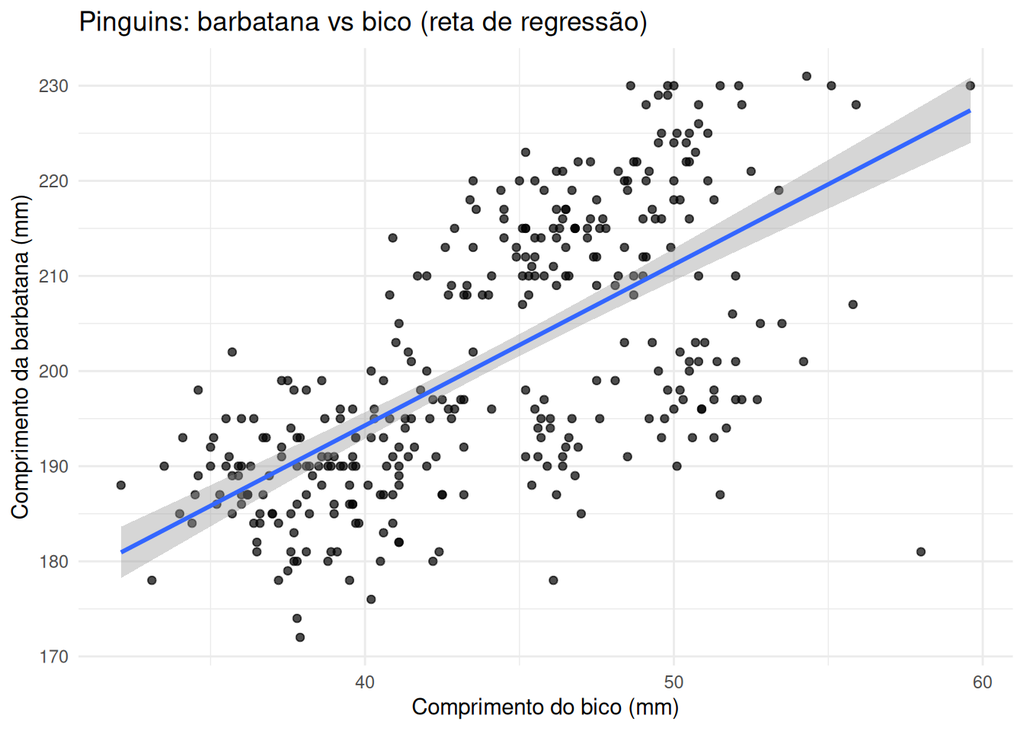

```r
peng <- penguins |> drop_na(flipper_length_mm, bill_length_mm)

ggplot(peng, aes(bill_length_mm, flipper_length_mm)) +
  geom_point(alpha = 0.7) +
  geom_smooth(method = "lm", se = TRUE) +
  labs(x = "Comprimento do bico (mm)",
       y = "Comprimento da barbatana (mm)",
       title = "Pinguins: barbatana vs bico (reta de regressão)")
```

**Interpretação.** O diagrama sugere **relação positiva**: pinguins com bicos mais longos tendem a ter barbatanas mais longas.

## 2. Ajuste do modelo e resumo

```r
mod_peng <- lm(flipper_length_mm ~ bill_length_mm, data = peng)
summary(mod_peng)
```

```
##
## Call:
## lm(formula = flipper_length_mm ~ bill_length_mm, data = peng)
##
## Residuals:
##    Min     1Q Median     3Q    Max
## -43.71  -7.90   0.66   8.65  21.18
##
## Coefficients:
##                Estimate Std. Error t value Pr(>|t|)
## (Intercept)     126.684      4.665    27.2   <2e-16 ***
## bill_length_mm    1.690      0.105    16.0   <2e-16 ***
## ---
## Signif. codes:  0 '***' 0.001 '**' 0.01 '*' 0.05 '.' 0.1 ' ' 1
##
## Residual standard error: 10.6 on 340 degrees of freedom
## Multiple R-squared:  0.431,  Adjusted R-squared:  0.429
## F-statistic:  257 on 1 and 340 DF,  p-value: <2e-16
```

```r
tidy(mod_peng, conf.int = TRUE)
```

```
## # A tibble: 2 × 7
##   term           estimate std.error statistic  p.value conf.low conf.high
##   <chr>             <dbl>     <dbl>     <dbl>    <dbl>    <dbl>     <dbl>
## 1 (Intercept)      127.       4.67       27.2 3.65e-87   118.      136.
## 2 bill_length_mm     1.69     0.105      16.0 1.74e-43     1.48      1.90
```

```r
glance(mod_peng)[,c("r.squared","adj.r.squared","sigma")]
```

```
## # A tibble: 1 × 3
##   r.squared adj.r.squared sigma
##       <dbl>         <dbl> <dbl>
## 1     0.431         0.429  10.6
```

**Interpretação.**  
- **Declive** (> 0): aumento de 1 mm no bico associa-se, em média, a aumento de ~1.69 mm na barbatana.  
- **Intercept**: comprimento médio da barbatana quando o bico é 0 mm (não tem interpretação biológica direta; serve para posicionar a reta).  
- O $R^2$ indica a fração da variabilidade da barbatana explicada pelo bico (tipicamente moderada).

## 3. Predição e intervalo de predição para `bill_length_mm = 45`

```r
novo_peng <- tibble(bill_length_mm = 45)
predict(mod_peng, newdata = novo_peng, interval = "prediction", level = 0.95)
```

```
##     fit   lwr   upr
## 1 202.7 181.8 223.7
```

**Interpretação.** A **predição pontual** é o valor esperado da barbatana para bico=45mm. O **intervalo de predição** é mais largo que um IC de média, pois incorpora a variabilidade individual além da incerteza dos parâmetros.

## 4. Diagnóstico de resíduos

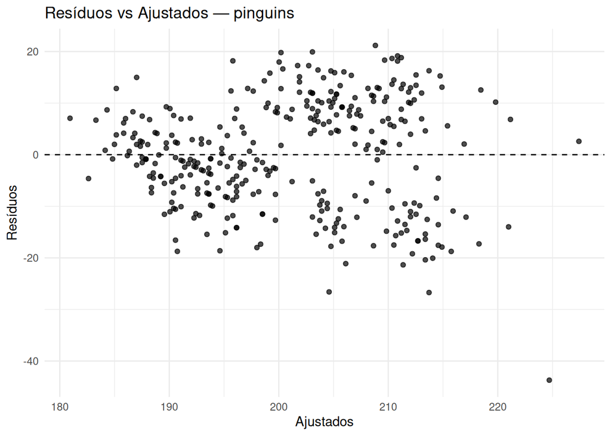

```r
augment(mod_peng) |>
  ggplot(aes(.fitted, .resid)) +
  geom_hline(yintercept = 0, linetype = 2) +
  geom_point(alpha = 0.7) +
  labs(x = "Ajustados", y = "Resíduos", title = "Resíduos vs Ajustados — pinguins")
```

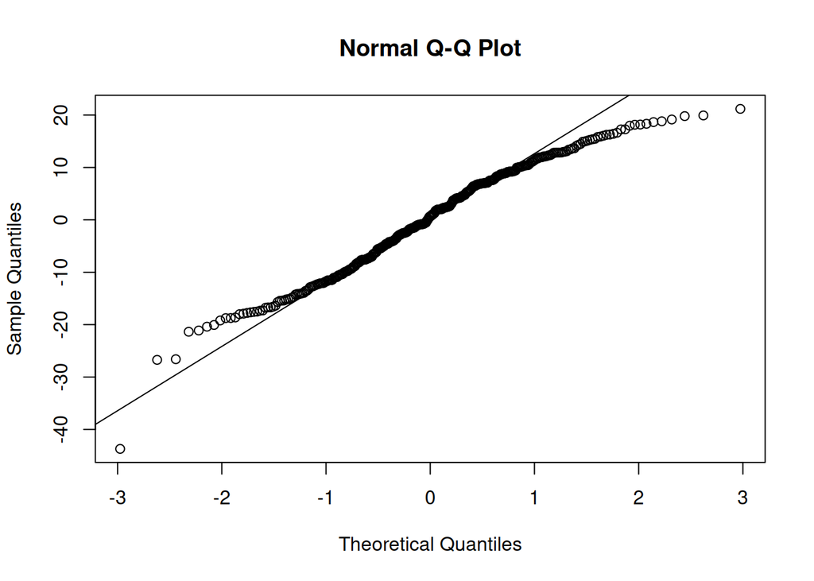

```r
qqnorm(resid(mod_peng)); qqline(resid(mod_peng))
```

# Exercício 2 — Diamantes: preço e quilates (ggplot2::diamonds)

## 1–2. Ajuste linear simples e $R^2$

```r
data(diamonds, package = "ggplot2")

mod_d_lin <- lm(price ~ carat, data = diamonds)
summary(mod_d_lin)$r.squared
```

```
## [1] 0.8493
```

```r
glance(mod_d_lin)[, c("r.squared","adj.r.squared","sigma")]
```

```
## # A tibble: 1 × 3
##   r.squared adj.r.squared sigma
##       <dbl>         <dbl> <dbl>
## 1     0.849         0.849 1549.
```

## 3. Comparação com escala log–log

```r
mod_d_log <- lm(log(price) ~ log(carat), data = diamonds)
bind_rows(
  glance(mod_d_lin) |> mutate(modelo = "price ~ carat"),
  glance(mod_d_log) |> mutate(modelo = "log(price) ~ log(carat)")
) |>
  select(modelo, r.squared, adj.r.squared, sigma, AIC, BIC)
```

```
## # A tibble: 2 × 6
##   modelo                  r.squared adj.r.squared    sigma     AIC     BIC
##   <chr>                       <dbl>         <dbl>    <dbl>   <dbl>   <dbl>
## 1 price ~ carat               0.849         0.849 1549.    945467. 945493.
## 2 log(price) ~ log(carat)     0.933         0.933    0.263   8854.   8881.
```

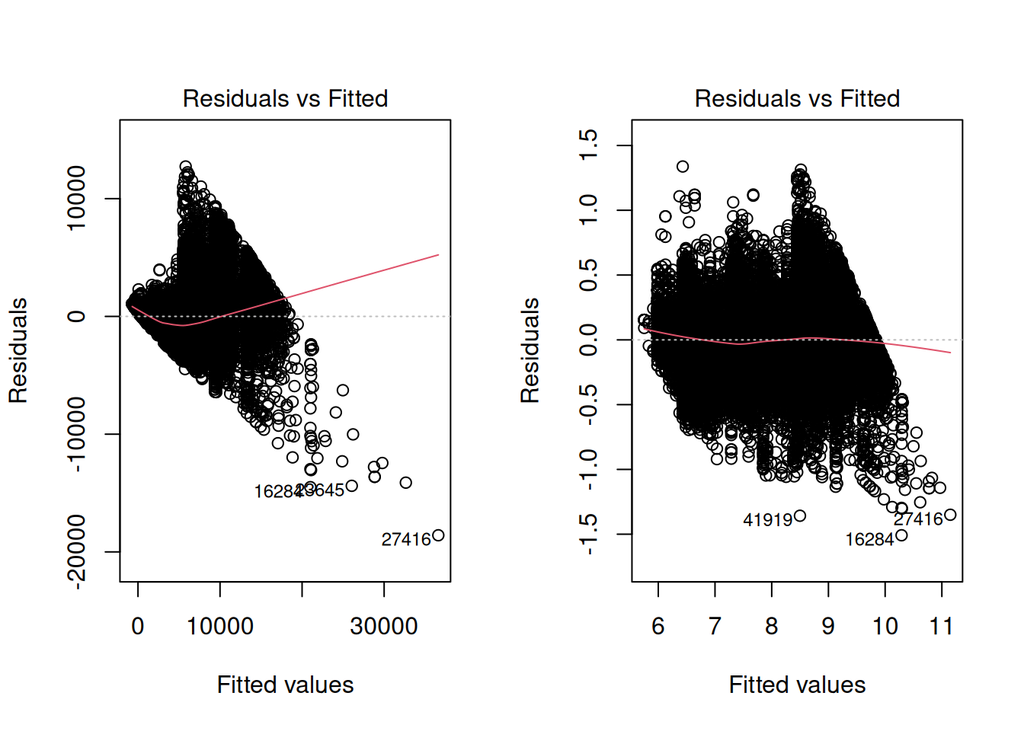

```r
par(mfrow=c(1,2))
plot(mod_d_lin, which = 1)     # resíduos vs ajustados
plot(mod_d_log, which = 1)
```

```r
par(mfrow=c(1,1))
```

**Interpretação.** Em geral, **log–log** melhora a homocedasticidade e lineariza a relação preço–quilates (potência).

## 4. Predição para `carat = 1.0` (no modelo escolhido)

```r
novo_d <- tibble(carat = 1.0)

# Exemplo: usando o modelo log–log (substitua se optar pelo linear)
pred_log <- predict(mod_d_log, newdata = tibble(carat = 1.0),
                    interval = "prediction", level = 0.95)
# Reverter log para escala original:
exp(pred_log)
```

```
##    fit  lwr  upr
## 1 4669 2790 7813
```

**Interpretação.** O intervalo de predição em escala original reflete a grande variabilidade do preço para um mesmo peso.

# Exercício 3 — Países: esperança média de vida e PIB (gapminder)

## 1–2. Seleção do ano e comparação de modelos

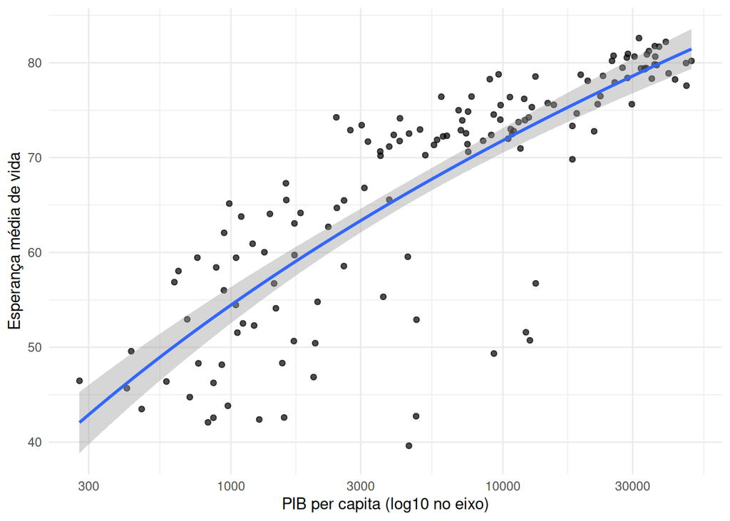

```r
gm <- gapminder |> filter(year == 2007)

# Gráfico com escala log no eixo x
ggplot(gm, aes(gdpPercap, lifeExp)) +
  geom_point(alpha = 0.7) +
  scale_x_log10() +
  geom_smooth(method = "lm", formula = y ~ log(x), se = TRUE) +
  labs(x = "PIB per capita (log10 no eixo)", y = "Esperança média de vida")
```

```r
m_lin <- lm(lifeExp ~ gdpPercap, data = gm)
m_log <- lm(lifeExp ~ log(gdpPercap), data = gm)

bind_rows(
  glance(m_lin) |> mutate(modelo = "lifeExp ~ gdpPercap"),
  glance(m_log) |> mutate(modelo = "lifeExp ~ log(gdpPercap)")
) |>
  select(modelo, r.squared, adj.r.squared, sigma, AIC, BIC)
```

```
## # A tibble: 2 × 6
##   modelo                   r.squared adj.r.squared sigma   AIC   BIC
##   <chr>                        <dbl>         <dbl> <dbl> <dbl> <dbl>
## 1 lifeExp ~ gdpPercap          0.461         0.457  8.90 1028. 1037.
## 2 lifeExp ~ log(gdpPercap)     0.654         0.652  7.12  965.  973.
```

## 3. Interpretação do declive do melhor modelo

```r
tidy(m_log, conf.int = TRUE)
```

```
## # A tibble: 2 × 7
##   term           estimate std.error statistic  p.value conf.low conf.high
##   <chr>             <dbl>     <dbl>     <dbl>    <dbl>    <dbl>     <dbl>
## 1 (Intercept)        4.95     3.86       1.28 2.02e- 1    -2.68     12.6
## 2 log(gdpPercap)     7.20     0.442     16.3  4.12e-34     6.33      8.08
```

**Interpretação.** No modelo `lifeExp ~ log(gdpPercap)`, um aumento proporcional do PIB (ex.: ~$e$ vezes) está associado a um aumento **aditivo** na esperança de vida de magnitude igual ao declive. Em termos práticos: “**dobrar** o PIB per capita está associado a ≈ 4.99 anos a mais de vida, em média.”

## 4. Resíduos

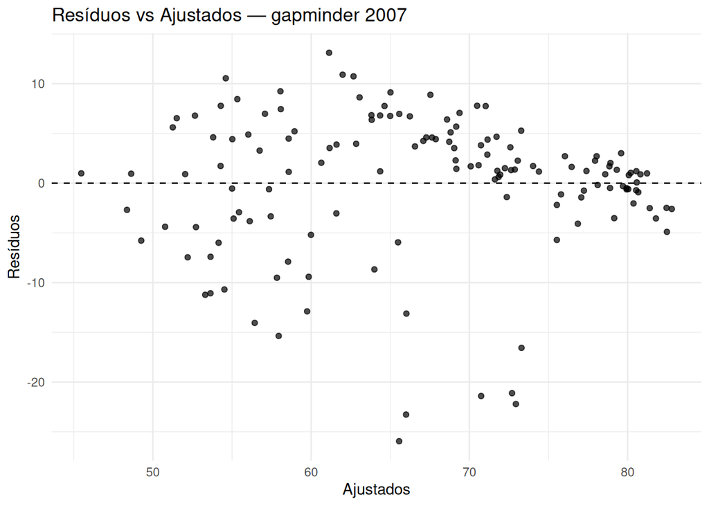

```r
augment(m_log) |>
  ggplot(aes(.fitted, .resid)) +
  geom_hline(yintercept = 0, linetype = 2) +
  geom_point(alpha = 0.7) +
  labs(x = "Ajustados", y = "Resíduos", title = "Resíduos vs Ajustados — gapminder 2007")
```

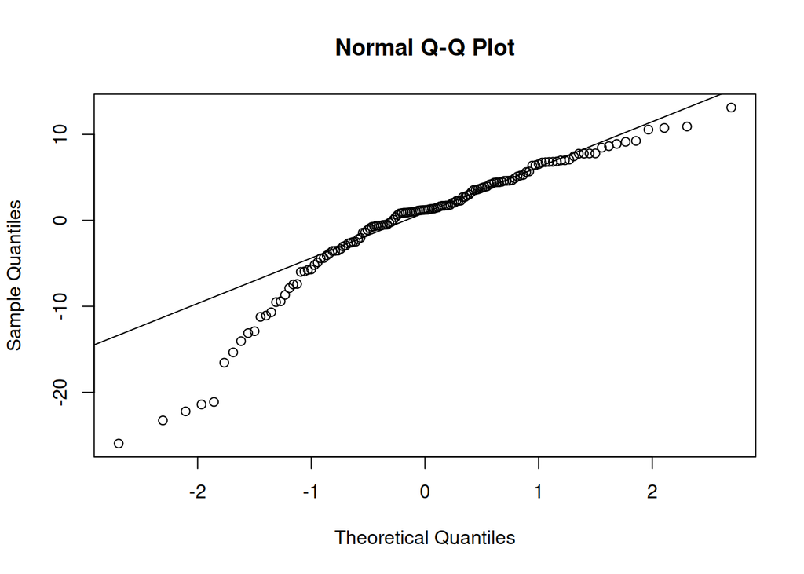

```r
qqnorm(resid(m_log)); qqline(resid(m_log))
```

**Interpretação.** Espera-se padrão mais homogéneo e resíduos mais centrados em zero com a transformação log no PIB.

# Exercício 4 — Voos: atraso e distância (nycflights13)

> Para gráficos e diagnóstico mais leves, trabalharemos com uma **amostra** estratificada por mês.

## 1–2. Gráfico e modelo

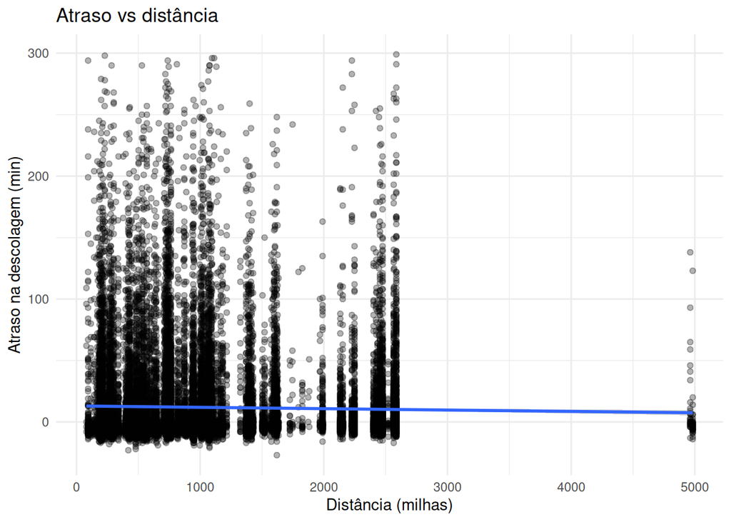

```r
fl <- flights |>
  drop_na(dep_delay, distance) |>
  filter(between(dep_delay, -30, 300)) |>
  group_by(month) |>
  slice_sample(prop = 0.1) |>
  ungroup()

ggplot(fl, aes(distance, dep_delay)) +
  geom_point(alpha = 0.3) +
  geom_smooth(method = "lm", se = TRUE) +
  labs(x = "Distância (milhas)", y = "Atraso na descolagem (min)",
       title = "Atraso vs distância")
```

```r
m_dep <- lm(dep_delay ~ distance, data = fl)
summary(m_dep)
```

```
##
## Call:
## lm(formula = dep_delay ~ distance, data = fl)
##
## Residuals:
##    Min     1Q Median     3Q    Max
## -38.24 -16.91 -13.21  -0.98 288.83
##
## Coefficients:
##              Estimate Std. Error t value Pr(>|t|)
## (Intercept) 13.031436   0.349291   37.31  < 2e-16 ***
## distance    -0.001108   0.000272   -4.08  4.6e-05 ***
## ---
## Signif. codes:  0 '***' 0.001 '**' 0.01 '*' 0.05 '.' 0.1 ' ' 1
##
## Residual standard error: 36.2 on 32782 degrees of freedom
## Multiple R-squared:  0.000506,   Adjusted R-squared:  0.000476
## F-statistic: 16.6 on 1 and 32782 DF,  p-value: 4.6e-05
```

```r
tidy(m_dep, conf.int = TRUE)
```

```
## # A tibble: 2 × 7
##   term        estimate std.error statistic   p.value conf.low conf.high
##   <chr>          <dbl>     <dbl>     <dbl>     <dbl>    <dbl>     <dbl>
## 1 (Intercept) 13.0      0.349        37.3  2.14e-298 12.3     13.7
## 2 distance    -0.00111  0.000272     -4.08 4.60e-  5 -0.00164 -0.000575
```

## 3. Influência de outliers (remoção do mais influente)

```r
aug <- augment(m_dep)
cutoff <- 4/nrow(fl)

# Top influentes por distância de Cook
aug |> arrange(desc(.cooksd)) |> slice_head(n = 5)
```

```
## # A tibble: 5 × 8
##   dep_delay distance .fitted .resid     .hat .sigma .cooksd .std.resid
##       <dbl>    <dbl>   <dbl>  <dbl>    <dbl>  <dbl>   <dbl>      <dbl>
## 1       138     4963    7.53   130. 0.000892   36.2 0.00580       3.60
## 2       299     2586   10.2    289. 0.000163   36.2 0.00518       7.98
## 3       291     2586   10.2    281. 0.000163   36.2 0.00490       7.76
## 4       123     4983    7.51   115. 0.000901   36.2 0.00459       3.19
## 5       272     2586   10.2    262. 0.000163   36.2 0.00426       7.23
```

```r
# Remover o mais influente e reestimar
i_max <- which.max(aug$.cooksd)
fl2 <- fl[-i_max, ]
m_dep2 <- lm(dep_delay ~ distance, data = fl2)

bind_rows(
  tidy(m_dep)  |> mutate(modelo = "com todos"),
  tidy(m_dep2) |> mutate(modelo = "sem o mais influente")
) |>
  filter(term == "distance")
```

```
## # A tibble: 2 × 6
##   term     estimate std.error statistic   p.value modelo
##   <chr>       <dbl>     <dbl>     <dbl>     <dbl> <chr>
## 1 distance -0.00111  0.000272     -4.08 0.0000460 com todos
## 2 distance -0.00114  0.000272     -4.18 0.0000292 sem o mais influente
```

**Interpretação.** Compare a inclinação antes/depois. Se a mudança for pequena, a conclusão é robusta; se mudar muito, o ajuste estava dominado por poucos pontos.

## 4. Limitações

**Interpretação textual.** Usar apenas `distance` ignora clima, horário, companhia, aeroporto, conexão, congestionamento etc. A variância residual alta sugere necessidade de mais preditores ou ou outros modelos.

# Exercício 5 — Predição para subgrupos (diamantes)

## 1–4. Modelos separados por lapidação

```r
subcuts <- c("Ideal","Good")
dsub <- diamonds |> filter(cut %in% subcuts)

mods_by_cut <- dsub |>
  group_by(cut) |>
  group_map(~ lm(price ~ carat, data = .x), keep = TRUE)
# Tabela comparativa das inclinações e R2 por subgrupo
tbl_slopes <- dsub |>
  group_by(cut) |>
  do(tidy(lm(price ~ carat, data = .))) |>
  filter(term == "carat") |>
  select(cut, estimate, std.error, p.value)

tbl_fit <- dsub |>
  group_by(cut) |>
  do(glance(lm(price ~ carat, data = .))) |>
  select(cut, r.squared, adj.r.squared, sigma)

list(tbl_slopes = tbl_slopes, tbl_fit = tbl_fit)
```

```
## $tbl_slopes
## # A tibble: 2 × 4
## # Groups:   cut [2]
##   cut   estimate std.error p.value
##   <ord>    <dbl>     <dbl>   <dbl>
## 1 Good     7480.      44.7       0
## 2 Ideal    8192.      21.8       0
##
## $tbl_fit
## # A tibble: 2 × 4
## # Groups:   cut [2]
##   cut   r.squared adj.r.squared sigma
##   <ord>     <dbl>         <dbl> <dbl>
## 1 Good      0.851         0.851 1421.
## 2 Ideal     0.867         0.867 1388.
```

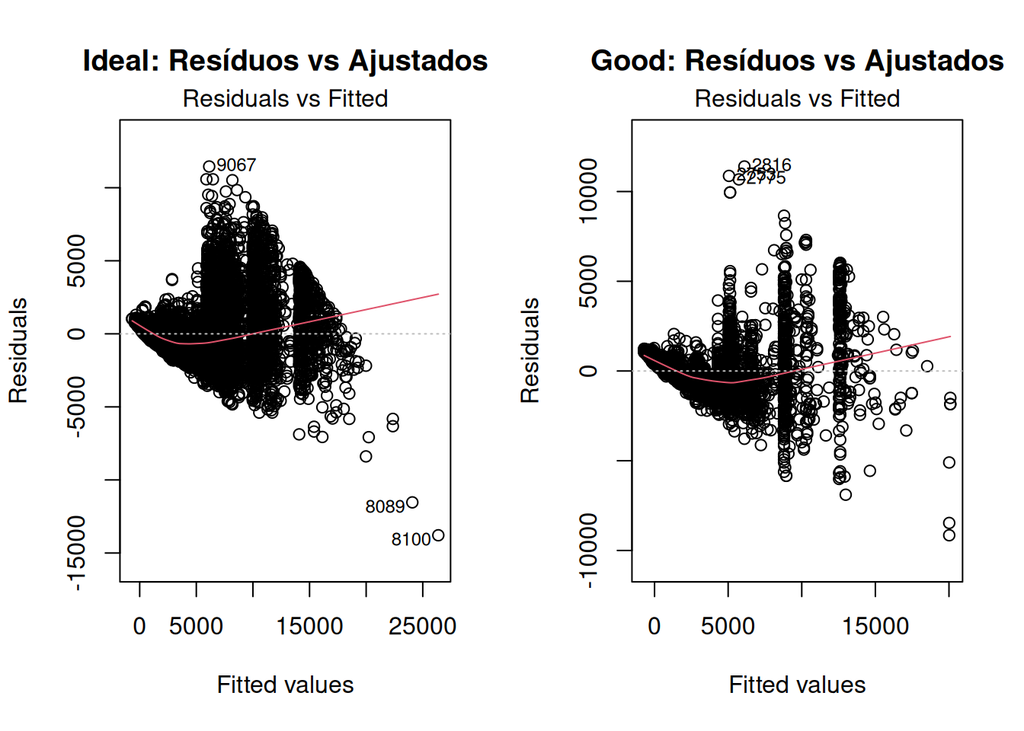

```r
# Resíduos por subgrupo
par(mfrow=c(1,2))
plot(lm(price ~ carat, data = filter(dsub, cut=="Ideal")), which = 1, main = "Ideal: Resíduos vs Ajustados")
plot(lm(price ~ carat, data = filter(dsub, cut=="Good")),  which = 1, main = "Good: Resíduos vs Ajustados")
```

```r
par(mfrow=c(1,1))
```

**Interpretação.** As inclinações podem diferir entre *cuts* por qualidade de lapidação (valor agregado). Resíduos podem mostrar heterocedasticidade, sugerindo uso de transformações (*e.g.*, log–log) em análises futuras.